Over the course of this project we built a total of five models:

- An OLS model on the training data
- A Ridge model, using 10-fold cross validation to select lambda, on the training data
- A Lasso model, using 10-fold cross validation to select lambda, on the training data
- A PCR model, using 10-fold cross validation to select the number of components, on the training data
- A PLSR model, using 10-fold cross validation to select the number of components, on the training data

Each model was built using a scaled and centered version of the raw data. To ensure consistency we divide the data into test/training sets once and use the same sets to train and test each model.

Each model (excluding OLS) required a tuning parameter be definied, lambda values for Ridge and Lasso, and the number of components for PCR and PLS. To decide thse tuning parameters we used cross validation, below are the plots of prediction intervals for the MSE of the Ridge and Lasso methods as a function of different lambda values:

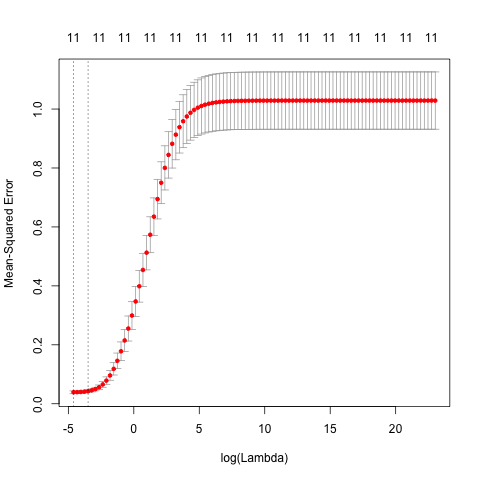

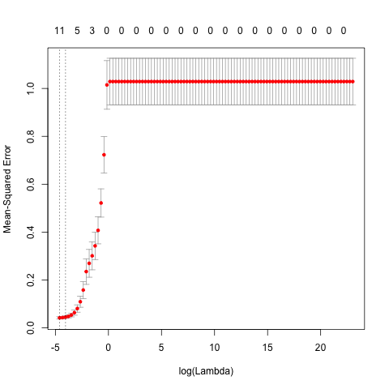

Next we consider the plots for MSEP as a function of the number of components taken in the PCR and PLS methods:

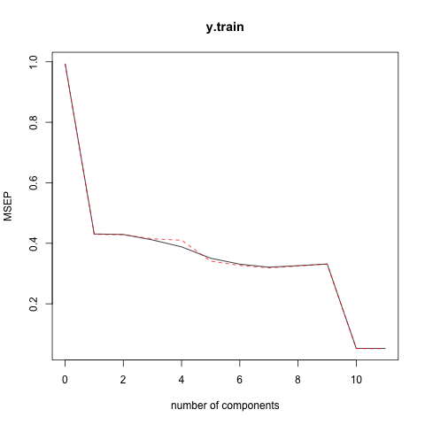

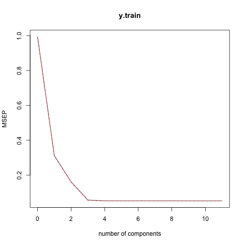

We simply take the minimal value (lambda or #-components depending on the model) of each plot and use that value as the tuning parameter for our full models.

Below is a table of the regression coefficients produced by each model on the full data:

Model Coefficients

|  | lm | ridge | lasso | pls | pcr |
| --- | --- | --- | --- | --- | --- |
| Income | -0.59 | -0.57 | -0.55 | -0.60 | -0.60 |
| Limit | 0.98 | 0.72 | 0.93 | 0.96 | 0.96 |
| Rating | 0.34 | 0.59 | 0.37 | 0.38 | 0.38 |
| Cards | 0.06 | 0.04 | 0.04 | 0.05 | 0.05 |
| Age | -0.02 | -0.03 | -0.02 | -0.02 | -0.02 |
| Education | 0.01 | -0.01 | 0.00 | -0.01 | -0.01 |
| GenderFemale | -0.01 | -0.01 | 0.00 | -0.01 | -0.01 |
| StudentYes | 0.27 | 0.27 | 0.27 | 0.28 | 0.28 |
| MarriedYes | -0.00 | -0.01 | 0.00 | -0.01 | -0.01 |
| EthnicityAsian | 0.01 | 0.02 | 0.00 | 0.02 | 0.02 |
| EthnicityCaucasian | 0.02 | 0.01 | 0.00 | 0.01 | 0.01 |

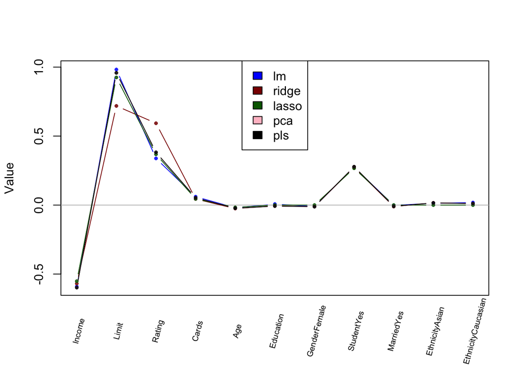

From this we deduce that `Education`, `GenderFemale`, `MarriedYes`, `EthnicityAsian`, and `EthnicityCaucasian` are all *meaningless* in our lasso regression. Reducing the number of regressors in our model allows us to easily interpret the results and increases the overall effectiveness of our model. This is why we consider lasso-regression to be a dimmension reduction method, since it tends (as the number of regressors increases) to send the coefficients of regressors with little predictive power to 0. In short, the lasso-regression identified the `Education`, `GenderFemale`, `MarriedYes`, `EthnicityAsian`, and `EthnicityCaucasian` as unimportant variables and set their regression coefficients to 0.

The second dimmension reduction method is ridge-regression. In contrast to the lasso, the ridge pentaly term uses the L-2 norm of the Betas. While this may seem arbitrary, this reduces the probability of unimportant regressor coefficients being 0. Upon further inspection we note that the `Education`, `GenderFemale`, `MarriedYes`, `EthnicityAsian`, and `EthnicityCaucasian` regressors have comparatively low coefficient magnitueds, which further supports the thoery that these variables are less important to our regression. This leads us to believe both the Ridge and Lasso models will yield similar results.